# Using Docker for deploying R APIs

3 March 2022

## Introduction

- A walk through of using Docker to deploy an API written in R
- Example is a modified version of a phase 2 assist
- [Plumber](https://www.rplumber.io/) used to build API
- [Docker](https://www.docker.com/) used to deploy
- [nginx](https://www.nginx.com/) used to provide authentication and (eventually) https
- (Bonus feature) - these slides are rendered using [Github Actions](https://github.com/features/actions)

## Example data

Price of cut diamonds:

- Carat - weight of diamond
- Cut - quality of the cut (Fair, Good, Very Good, Premium, Ideal)
- Colour - colour of the diamond (D (best) to J (worst))
- Some other variables I didn’t use

53940 observations

(Based on model in [R for Data Science](https://r4ds.had.co.nz/model-building.html))

## Example data

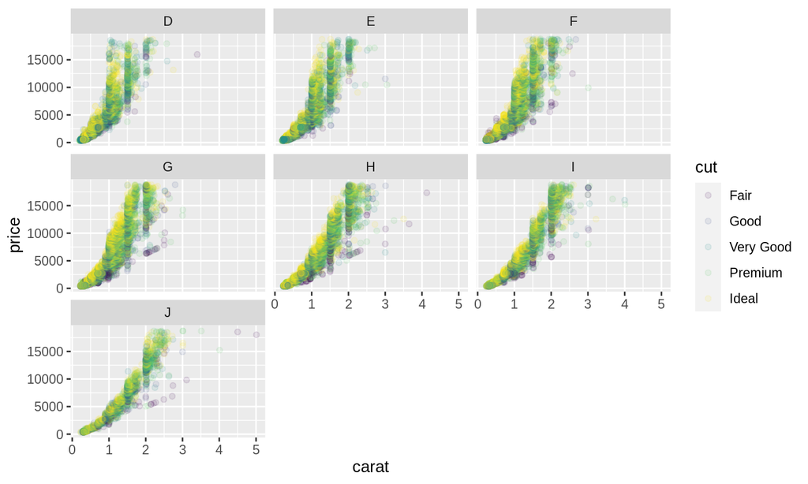

## Fitted model

Linear model, using \(\log(\mbox{price})\) as response:

```
## lprice ~ carat + color + cut
```

\(r^2=\) 0.87

Haven’t done any model checking - can undoubtedly do better.

## Model predictions

- Pass a data.frame containing new values to `predict()`

```r
predictvals <- tribble(~carat, ~color, ~cut,
                       1.5, "E", "Very Good")
exp(predict(mod_diamond, predictvals))
```

```
##        1
## 11182.31
```

```r
exp(predict(mod_diamond, predictvals, interval = "pred"))
```

```
##        fit      lwr      upr
## 1 11182.31 5415.239 23091.14
```

## Plumber

(Closest Python equivalents are probably [Flask](https://flask.palletsprojects.com/en/2.0.x/) or [FastAPI](https://fastapi.tiangolo.com/))

```r
#* Return the sum of two numbers
#* @param a The first number to add
#* @param b The second number to add
#* @post /sum
function(a, b) {
    as.numeric(a) + as.numeric(b)
}
```

- Generates Swagger docs automatically.
- R isn’t ideal for APIs - single threaded.
  - Various workarounds.

## Docker

- Container for code and runtime environment (*kind of* like a VM)
- Self-contained
- Many pre-built images available; I used `rstudio/plumber`

## Dockerfile

```
FROM rstudio/plumber
MAINTAINER David Mawdsley <david.mawdsley@manchester.ac.uk>

RUN R -e "install.packages(c('magrittr', 'tibble', 'dplyr' ))"

COPY plumber.R /
COPY data /data


CMD ["/plumber.R"]
```

## Docker - Build the container:

```bash
docker build -t diamondpredict .
```

Pulls in `rstudio/plumber`, and creates new “layers” as required. Cached.

And run:

```bash
docker run -p 127.0.0.1:8000:8000 diamondpredict
```

`-p` option maps port 8000 in “dockerland” to port 8000 on the actual machine, listening on localhost

## Authentication

- Reverse proxy - forwards requests to API from outside world
- Using nginx to provide basic http authentication
  - Could use other authentication methods
- Can also be used to:
  - Set up https access
  - Load balance

`docker-compose` sets up nginx container and “dockerland” internal network

## Authentication (2)

```
version: '2'
services:
        diamondpredict:
                image: diamondpredict
                command: /plumber.R
                restart: "no"
        nginx:
                image: nginx:1.9
                ports:
                        - "80:80"
                volumes:
                        - ./nginx.conf:/etc/nginx/nginx.conf:ro
                        - ./.htpasswd:/etc/apache2/.htpasswd:ro
                restart: "no"
                depends_on:
                        - diamondpredict
```

## Moving to another system

Dump the container to a file:

```bash
docker save diamondpredict:latest |bzip2 > diamondpredict.tar.bz2
```

Move file to new system…

Load with:

```bash
docker load -i diamondpredict.tar.bz2
```

(Ideally you’d use a Docker Hub or a private Docker Registry)

## Summary

- Plumber provides an easy way for use to bolt an API onto our models
- Docker makes it easier to share and deploy the API
- Nginx lets us provide authentication, https, load balancing

## (Bonus) Github Actions

- R Markdown slides are rendered to html and published using Github Pages
- Github Actions:
  - Set up R environment (using `renv` \(\approx\) Python’s `venv`)
  - Render slides
  - Commit
  - Triggers Github pages “publish” workflow